# Shockbox Analysis

Isla Weber

5/6/2021

load necessary libraries

```r
library(ggplot2)
library(readr)
library(tidyr)
```

# Import data

To import, *replace the filepath* below with the appropriate path location. (Run getwd() in the console to see where the filepath should start from, should be folder where this file is saved). Must be a csv file formatted with the following column names: - *freezing* :: percent of time spent freezing, should just be a number - *id* :: contains the mouse ID (can be letters and/or numbers) - *day* :: contains the day of the experiment, written as the following: sefla, seflb, recall1, recall2, recall3, recall4, recall5 - *condition* :: contains the mouse condition, written as the following: control, ptsd

*change the cohort variable to current cohort when you analyze!!*

```r
data <- read_csv("PTSD1_freezing.csv")
cohort <- "PTSD1"
data_wide <- spread(data, day, freezing)
head(data)
```

```
## # A tibble: 6 x 4
##   freezing id            day   condition
##      <dbl> <chr>         <chr> <chr>
## 1     3.51 5HT2Afl05a-5  sefla control
## 2     3.08 5HT2Afl05a-7  sefla control
## 3     0.8  5HT2ACre01a-3 sefla control
## 4     0.7  sert26a-3     sefla control
## 5    45.1  5HT2Afl5a-6   sefla ptsd
## 6    38.1  5HT2ACre01a-2 sefla ptsd
```

```r
head(data_wide)
```

```
## # A tibble: 6 x 9
##   id            condition recall1 recall2 recall3 recall4 recall5 sefla seflb
##   <chr>         <chr>       <dbl>   <dbl>   <dbl>   <dbl>   <dbl> <dbl> <dbl>
## 1 5HT2ACre01a-1 ptsd         46.8    21.3   NA      NA      NA    59.7  11.3
## 2 5HT2ACre01a-2 ptsd         41.3    15.4    2.23    7.03   11.8  38.1   9.45
## 3 5HT2ACre01a-3 control      30.1    15.0    4.1     4.99    3.21  0.8   2.52
## 4 5HT2Afl05a-5  control      43.1    22.6   37.2    26.1    43.3   3.51  8.94
## 5 5HT2Afl05a-7  control      35.5    23.9   36.4    46.0    47.3   3.08  4.53
## 6 5HT2Afl5a-6   ptsd         52.4    26.4   38.9    32.5    47.8  45.1  13.4
```

# Create Plots

This line is used to tell R what order we want the days to go in on the graph

```r
data$day <- factor(data$day, levels = c("sefla", "seflb", "recall1", "recall2", "recall3", "recall4", "recall5"))
```

The ggplot function loads the data and plots. It is very flexible, you can add a lot of features. To find a way to change or add to this, search something like “ggplot R barplot change colors” and you will find examples of code to try and incorporate.

The aes argument allows you to indicate the groups (fill), y axis (freezing), and x axis(day)

geom_bar adds the bar plot, geom_line adds the lines, geom_point adds the dots.

```r
#select the colors which will be associated with each group using universal color codes
group.colors = c(control = "#263FFF", ptsd = "#D80505")

#This will plot the averages in a bar plot then plot the lines for each mouse ID
groupedbar_line <- ggplot(data, aes(fill=condition, y=freezing, x=day)) +
    geom_bar(position="dodge", stat="summary", fun.y = "mean", alpha=.65)+
    geom_line(aes(x=day, y=freezing, group=id, colour=condition)) +
    geom_point(aes(x=day, y=freezing, group=id, colour=condition))+
    ggtitle("SEFL Freezing") + ylab("% freezing") +
    scale_x_discrete(labels=c("sefla" = "Context A", "seflb" = "Context B")) + scale_fill_manual(values=group.colors) + scale_color_manual(values=group.colors)
#This will plot the grouped bar plot plus the individual points
groupedbar_points <- ggplot(data, aes(fill=condition, y=freezing, x=day)) +
    geom_bar(position="dodge", stat="summary", fun.y = "mean", alpha=.8) +
    geom_point(aes(y=freezing, x=day),
           stat="identity",
           position = position_dodge(width = .9),
           alpha=1,
           size=.75) +
    ggtitle("SEFL Freezing") + ylab("% freezing") +
    scale_x_discrete(labels=c("sefla" = "Context A", "seflb" = "Context B")) + scale_fill_manual(values=group.colors) + scale_color_manual(values=group.colors)
#This will plot just the line plots for each mouse, color coded by group
line_by_id <- ggplot(data=data, aes(x=day, y=freezing, group=id, colour=condition)) + geom_line() + geom_point() +
    ggtitle("SEFL Freezing") + ylab("% freezing") +
    scale_x_discrete(labels=c("sefla" = "Context A", "seflb" = "Context B")) + scale_fill_manual(values=group.colors) + scale_color_manual(values=group.colors)
```

# Display Plots

```r
groupedbar_line
```

```
## No summary function supplied, defaulting to `mean_se()`
```

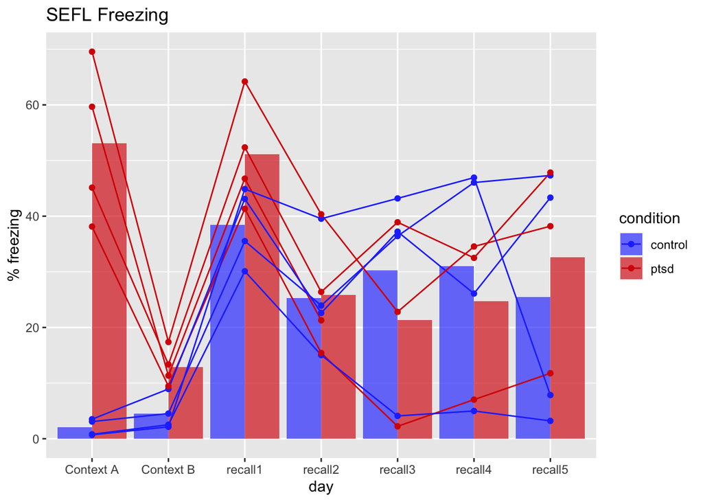

```r
groupedbar_points
```

```
## No summary function supplied, defaulting to `mean_se()`
```

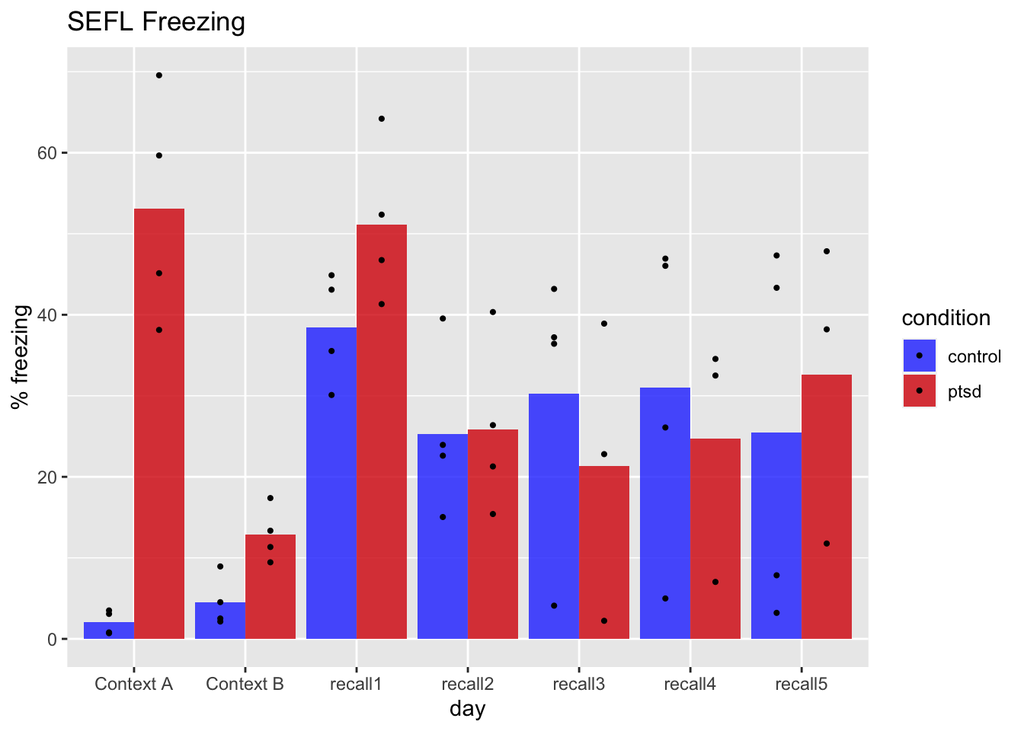

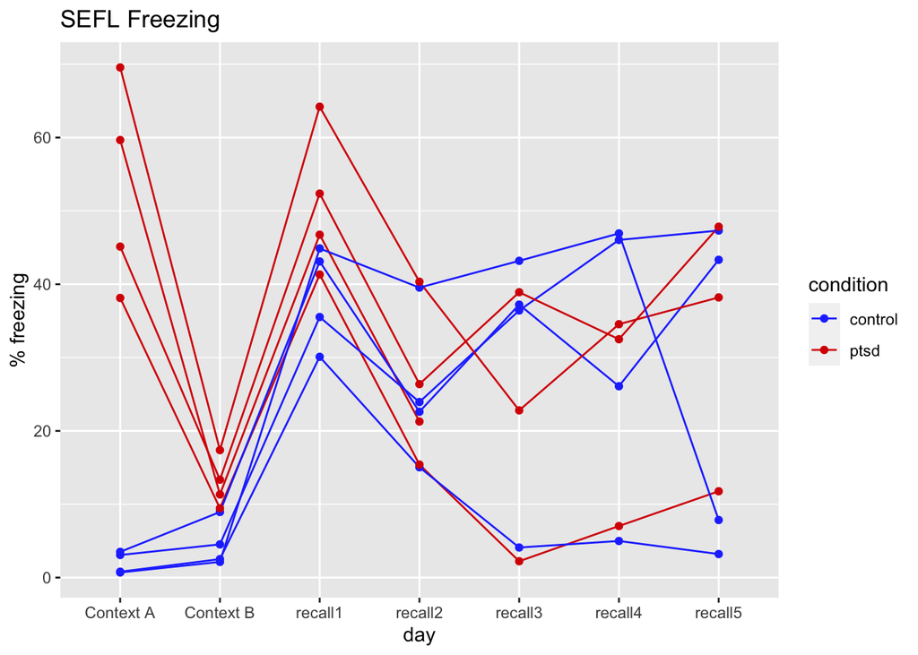

```r
line_by_id
```